# CW - data prep

In this document, you will learn how to process a data layer, and save it in `layers` folder.

We’ll also walk through the general steps we recommend you include in your own prep document, including:

- introducing the goal/subgoal, goal model, and data
- setting up directories and loading libraries
- loading and formatting data
- plotting
- saving as .csv in layers folder

*The following example was modified from the prep document for [OHI-Baltic Clean Water goal](https://github.com/OHI-Science/bhi/blob/draft/baltic2015/prep/CW/eutrophication/eutrophication_prep.Rmd). We have secchi depth data, which measures water clarity. The desired data layer will provide average summer secchi depth in each year and in each region. At the moment, we don’t know what the raw data looks like. We may need to aggregate and manipulate large quantities of data to get the final, clean data layer.*

# Introduction

*In this section you’ll describe the goal/subgoal, what types of information or data are needed, data sources, goal model, and how to approach trend calculation, etc.*

*For example, you can start with a general introduction of what this goal/subgoal is trying to measure, what it means in your local context, and what parameters make sense to be included or explored here.*

This subgoal aims to represent the eutrophication level in the water in each region. We uses summer time water clarity, measured by secchi depth, as a proxy indicator, assuming a linear relationship between water clarity and nutrient levels. More info on secchi depth can be found [here](http://www.helcom.fi/baltic-sea-trends/indicators/water-clarity).

## Goal model

*Record what the goal model and reference point should be, how to approach trend calculations, etc.*

### Status

Xao = Mean Stock Indicator Value / Reference pt

Stock indicators = two HELCOM core indicators assessed for good environmental status (each scored between 0 and 1 by BHI)

Reference pt = maximum possible good environmental status (value=1)

### Trend

*Typically we calculate trend as a linear trend of the last five years of status. In this assessment, however, this approach is not feasible. And an alternative approach is used and documented here.*

CPUE time series are available for all stations used for the HELCOM coastal fish populations core indicators. These data were provided by Jens Olsson (FISH PRO II project). To calculate GES status, full time series were used. Therefore, only one status time point and cannot calculate trend of status over time. Instead, we’ll follow approach from Bergström et al 2016, but only focus on the final time period for the slope (2004-2013).

Bergstrom et al. 2016. Long term changes in the status of coastal fish in the Baltic Sea. *Estuarin, Coast and Shelf Science*. 169:74-84

Method:

1. Select final time period of trend assessment (2004-2013)
2. Use time series from both indicators, Key Species and Functional groups. For functional groups,include both cyprinid and piscivore time series
3. For each time series: square-root transform data, z-score, fit linear regression, extract slope
4. Within each time series group (key species, cyprinid, piscivore), take the mean slope for each group within each basin
5. Within each basin take a mean functional group indicator slope (mean of cyprinid mean and piscivore mean)
6. For each basin take overall mean slope - mean of key species and functional group
7. Apply trend value for basin to all BHI regions (except in Gulf of Finland, do not apply Finnish site value to Estonia and Russian regions.)

## Data sources

*Here you can record where the data comes from, where it’s stored, potential concerns with the data, why you included or excluded certain data, etc:*

**ICE**: Data extracted from database and sent by Hjalte Parner on Feb 10 2016.

*Note from Parner: “extraction from our database classified into HELCOM Assessment Units – HELCOM sub basins with coastal WFD water bodies or water types”*

Pros and cons of using these data:

- Pros: these are the most recent published data and thus reflect the most current conditions of water quality…
- Cons: these datasets don’t have full spatial coverage, or don’t have even temporal coverage, and thus for some regions we need to do gap filling…

Reasons for excluding certain datasets:

Direct measurements of nutrient levels (eg. phosphate, nitrate, etc) were excluded from this subgoal because not every region measure these chemicals regularly, or we didn’t have time-series data on nutrients to be able to calculate trend…

# Data prep process

## Setup

This section will set up directories, functions, call commonly used libraries, etc, to prepare for the next steps of data prep.

## Read in data and initial exploration

ICES and SMHI data have non-overlapping observations and were combined to one data set for our use. Some observations were not assigned to any regions (ie. no region IDs attached) and were omitted.

Both data sets contains profile data (eg temperature, but secchi is only measured once). We need only unique secchi records. Duplicates were thus taken out.

*Basic functions we will encounter and you will use often: select, mutate, filter, rename*

```
## # A tibble: 6 x 13
##      X1 secchi BHI_ID Month  Year Assessment_unit HELCOM_COASTAL_CODE
##   <int>  <dbl>  <int> <int> <int> <chr>                         <int>
## 1     1   2.00      3     6  1972 DEN-012                          38
## 2     2   3.50      3     8  1972 DEN-012                          38
## 3     3   3.50      3     8  1972 DEN-012                          38
## 4     4   4.50      3    12  1972 DEN-012                          38
## 5     5   4.50      3    12  1972 DEN-012                          38
## 6     6   3.10      3     4  1973 DEN-012                          38
## # ... with 6 more variables: HELCOM_ID <chr>, Date <dttm>, Latitude <dbl>,
## #   Longitude <dbl>, Cruise <chr>, Station <chr>
```

[output not shown]

```
##   bhi_id secchi year month     lat    lon       date
## 1      3    2.0 1972     6 55.8517 9.9083 1972-06-06
## 2      3    3.5 1972     8 55.8517 9.9083 1972-08-01
## 3      3    3.5 1972     8 55.8517 9.9083 1972-08-01
## 4      3    4.5 1972    12 55.8517 9.9083 1972-12-04
## 5      3    4.5 1972    12 55.8517 9.9083 1972-12-04
## 6      3    3.1 1973     4 55.8517 9.9083 1973-04-12
```

```
## 'data.frame':    215543 obs. of  7 variables:
##  $ bhi_id: int  3 3 3 3 3 3 3 3 3 3 ...
##  $ secchi: num  2 3.5 3.5 4.5 4.5 3.1 3.1 1.8 1.8 2.5 ...
##  $ year  : int  1972 1972 1972 1972 1972 1973 1973 1973 1973 1973 ...
##  $ month : int  6 8 8 12 12 4 4 6 6 8 ...
##  $ lat   : num  55.9 55.9 55.9 55.9 55.9 ...
##  $ lon   : num  9.91 9.91 9.91 9.91 9.91 ...
##  $ date  : Date, format: "1972-06-06" "1972-08-01" ...
```

```
## [1] 1684
```

```
## [1] 180963
```

```
## [1] 32896
```

## Select only summer observations

- Months 6-9 (June, July, August, September)
- Years 2010-2015

*Plotting is a good way to spot data gaps and other potential problems. Without plotting, we might have missed these temporal gaps.*

```r
## select summer months
summer = new_ices %>% filter(month %in%c(6:9)) %>%
        filter(year %in% c(2010:2015))
head(summer)
```

```
##   bhi_id secchi year month     lat     lon       date
## 1     24    9.5 2012     6 56.3113 20.8297 2012-06-06
## 2     24    9.3 2012     6 56.4040 19.3545 2012-06-06
## 3     24    6.9 2012     6 56.3702 19.9957 2012-06-07
## 4     24    8.6 2012     6 56.7158 20.4372 2012-06-07
## 5     24    8.1 2012     6 57.3553 20.7755 2012-06-08
## 6     24    7.1 2012     6 57.4107 21.3267 2012-06-08
```

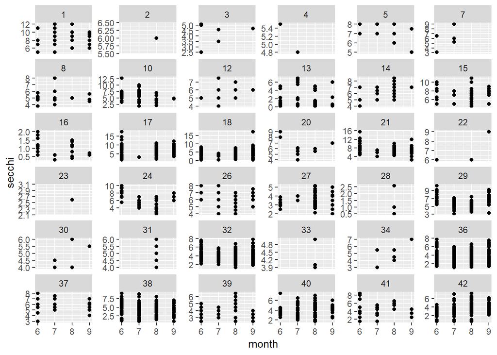

```r
## plot: by month
ggplot(summer) + geom_point(aes(month, secchi))+
  facet_wrap(~bhi_id, scales ="free_y")
```

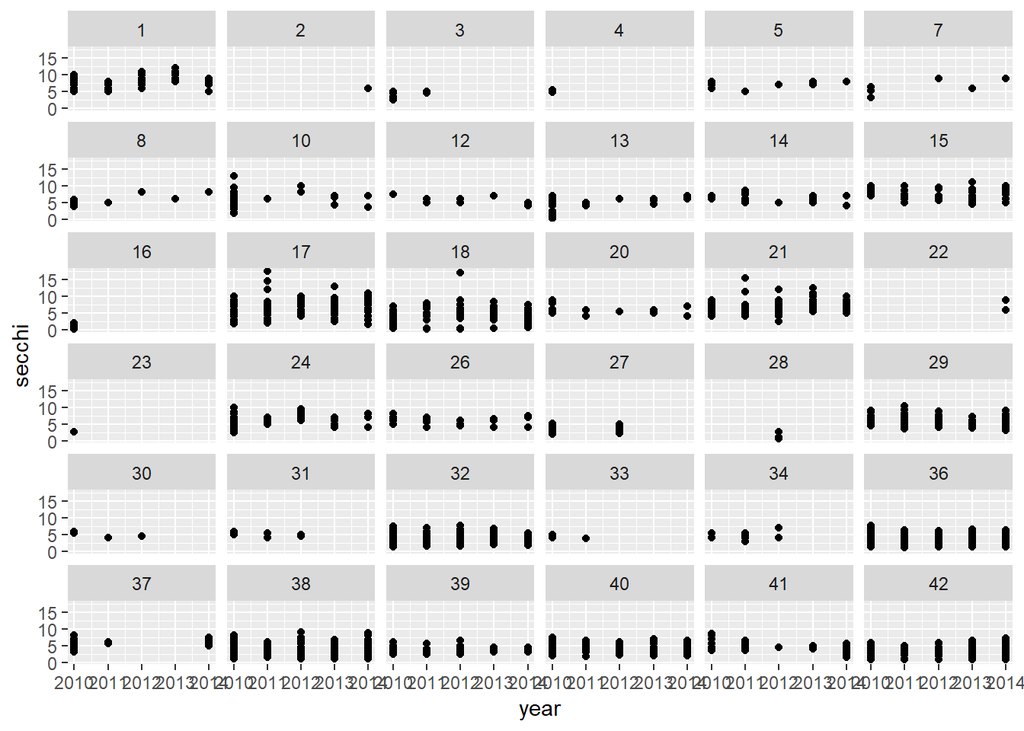

```r
## plot: by year
ggplot(summer) + geom_point(aes(year,secchi))+
  facet_wrap(~bhi_id)
```

## Calculate mean summer secchi depth by region

Here we calculated the mean summer secchi depth per year for each region.

*Plotting per region by year showed that not all regions have continuous and adequate data. There are differents ways to deal with that, which we will not explore today. You could read more on gapfilling in our [OHI Manual](http://ohi-science.org/manual/#gapfilling).*

```r
## calculate monthly means for each month
mean_months = summer %>% select(bhi_id, year, month, secchi) %>%
              group_by(bhi_id, year, month) %>%
              summarise(mean_secchi = round(mean(secchi, na.rm=TRUE), 1)) %>%
              ungroup()
head(mean_months)
```

```
## # A tibble: 6 x 4
##   bhi_id  year month mean_secchi
##    <int> <int> <int>       <dbl>
## 1      1  2010     6        7.40
## 2      1  2010     7        8.80
## 3      1  2010     8        9.50
## 4      1  2010     9        7.70
## 5      1  2011     6        6.00
## 6      1  2011     7        7.70
```

[output not shown]

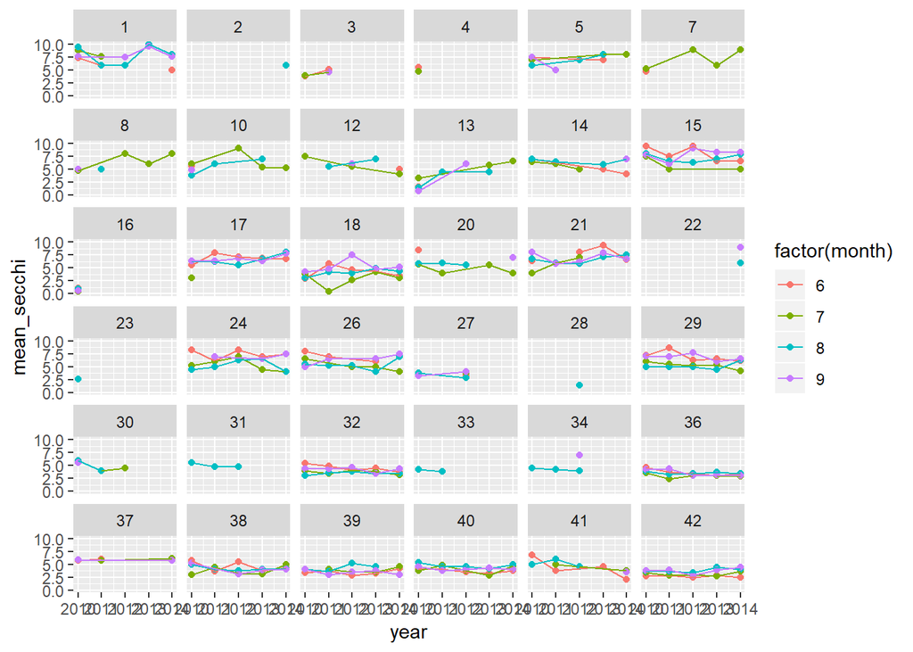

```r
## plot monthly means
ggplot(mean_months) + geom_point(aes(year,mean_secchi, colour=factor(month))) +
  geom_line(aes(year, mean_secchi, colour=factor(month))) +
  facet_wrap(~bhi_id)+
  scale_y_continuous(limits = c(0,10))
```

[output not shown]

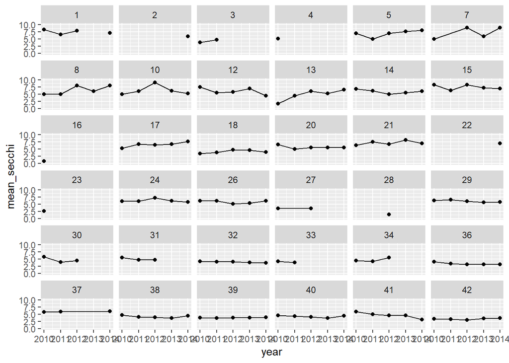

```r
## calculate summer means by region
## region summer means = mean of region monthly mean values

mean_months_summer = mean_months %>%
                      group_by(bhi_id, year)%>%
                      summarise(mean_secchi = round(mean(mean_secchi, na.rm=TRUE), 1)) %>%
                      ungroup()  %>%
  rename(rgn_id = bhi_id) #### rgn_id is a required field in a data layer!! ###

## plot summer means by basin
ggplot(mean_months_summer) +
  geom_point(aes(year,mean_secchi)) +
  geom_line(aes(year,mean_secchi))+
  facet_wrap(~rgn_id)+
  scale_y_continuous(limits = c(0,10))
```

*Congratulations! You have successfully wrangled a large dataset and produced a clean data layer. In order for the Toolbox to use it for calculation, we need to save it in the right location and register it. Let’s go back to the Training page for a minute and learn from there.*

## Save data layer to `layers` folder

When modifying existing or creating new data layers in the prep folder, save the ready-to-use layers in `layers` folder. We recommend saving it as a new *.csv* file with:

- a prefix identifying the goal (eg. `fis_`)
- a suffix identifying your assessment (eg. `_sc2016.csv`).

Modifying the layer name provides an easy way to track which data layers have been updated regionally, and which rely on global data. Then, the original layers (`_gl2016.csv` and `_gl2016placeholder.csv`) can be deleted.

**Tip**: filenames should not have any spaces: use an underscore instead. This will reduce problems when R reads the files.

```r
write_csv(mean_months_summer, file.path(dir_layers, "cw_mean_secchi_region2016.csv"))
```

**Last Step: To render this file and use it to communicate with other human beings**:

Click on *Knit* at the top of this window to create an .md file, which can be displayed online as a webpage. Pull/Commit/Push as usual for this file. Click on the .md file in your repo on Github.com to view the rendered file.

*Now we have saved the layer in `layers` folder, there is only one more thing left to do - register it in the data registry. Let’s switch back to where we left off in Training.*